# Drift diffusion model

Clara Kuper

Models of choice response times, model, estimation and extensions

General questions:

Why is a drift diffusion process sometimes modelled as ONE accumulator reaching bound A or B (=-A)and sometimes as two accumulators for plan A and B both going for one bound?

1. One drift rate, two bounds = activity in one population can trigger 2 different responses
2. Two drifts, one bound = action plans running in parallel

General about drift diffusion models:

7 parameters:

E = drift rate, varies from trial to trial, described by: v = mean drift rate n = standart deviatation of drift rate a = boundary separation z = starting point of diffusion process + variablity sz Ter= non-decision time + trial-to-trial variability st s = noise

3 parameters have no closed-loop solution: E, z and Ter. They vary with each trial and estimation n,sz and st is computationally demanding.

Therefore: fitting with toolbox rtdists

```r
library(rtdists)
library(ggplot2)
```

# reponse data is complicated :P

and therefore needs to be described with more than 2 parameters if we want to fit a drift diffusion model.

suggestion by farrell and lewandowski: fit model as quantile probability (proportion positive/negative choices in quantiles of rts)

```r
# application of a drift diffusion model, implementation after farrell and lewandowski

# for conveniance, store the names of the parameters
# only 6 params, because z is defined as 0.5 a within the function
names <- c("a","v","t0","sz","st0","sv")

# this function estimates the likelihoods of response data given 7 parameters and returns the summed likelihood, flipped to positive values

diffusionliglik <- function(pars,rt,response){
  likelihoods <- tryCatch(ddiffusion(rt,        #ddiffusion is a function from rtdist
                                     response = response, # which boundary was reached? upper/lower
                                     a = pars["a"],       # distance between boundaries
                                     v = pars["v"],       # mean drift rate
                                     t0= pars["t0"],      # non-decision time
                                     z = 0.5*pars["a"],   # start value on the middle between boundaries
                                     sz= pars["sz"],      # variability start value
                                     st0=pars["st0"],     # variability non-decison time
                                     sv= pars["sv"],      # variability mean drift
                                     s = .1,              # overall noise to scale with other parameters
                                     precision = 1),
                          error = function(e)0)
  if (any(likelihoods == 0)) return(1e6)
  return(-sum(log(likelihoods)))
}



# example use:

testparams <- c(.2,.5,.1,.02,.01,.1)
names(testparams) <- names

testRT <- rnorm(500,400,50)
testRES<- sample(c("lower","upper"),500,replace = TRUE)

diffusionliglik(testparams,testRT,testRES)
```

```
[1] 253974
```

```r
# to estimate the model, we first want to generate reaction time data

genparams <- c(.1,.2,.5,.05,.2,.05)
names(genparams) <- names
rts <- rdiffusion(500,a = genparams["a"],
                  v = genparams["v"],
                  t0= genparams["t0"],
                  z = 0.5*genparams["a"], d = 0,
                  sz= genparams["sz"],
                  sv= genparams["sv"],
                  st0=genparams["st0"], s = .1)


summary(rts)
```

```
       rt          response
 Min.   :0.5228   lower: 81
 1st Qu.:0.6702   upper:419
 Median :0.7501
 Mean   :0.7832
 3rd Qu.:0.8506
 Max.   :1.7508
```

```r
# starting values for parameters
sparms <- c(runif(1, 0.01, 0.4),
            runif(1,0.01, 0.5),
            0.3,
            runif(1,0.02,0.08),
            runif(1,.1,.3),
            runif(1,0,0.1))
names(sparms) <- names

# and estimate

fitparams <- optim(sparms, diffusionliglik, gr = NULL, rt=rts$rt, response = rts$response)
fitparams <- round(fitparams$par,3)
```

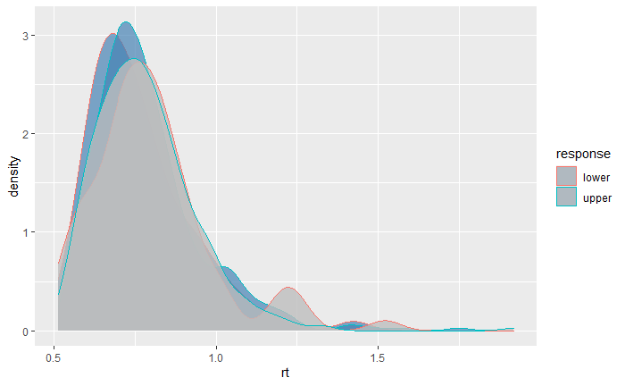

```r
# generate data with the new params
# plot both reaction time distributions
fitRTs <- rdiffusion(500,a = fitparams["a"],
                  v = fitparams["v"],
                  t0= fitparams["t0"],
                  z = 0.5*fitparams["a"], d = 0,
                  sz= fitparams["sz"],
                  sv= fitparams["sv"],
                  st0=fitparams["st0"], s = .1)

rts   <- as.data.frame(rts)
fitRTs<-as.data.frame(fitRTs)

## plotted as density distributions
## any better ideas for visualisation are welcome

plot <- ggplot(data=rts,aes(rt,colour=response))+
  geom_density(fill = "steelblue",alpha = 0.7)+
  geom_density(data=fitRTs, fill = "grey",alpha = 0.8)

plot
```

```r
# check if there is a difference between the two data sets, ignoring potential differences between lower and upper responses

diff <- t.test(rts$rt,fitRTs$rt)
diff
```

```
    Welch Two Sample t-test

data:  rts$rt and fitRTs$rt
t = -0.15518, df = 997.19, p-value = 0.8767
alternative hypothesis: true difference in means is not equal to 0
95 percent confidence interval:
 -0.02184134  0.01864017
sample estimates:
mean of x mean of y
0.7832273 0.7848278
```